# Cross references

¿Cómo insertar referencias cruzadas en documentos Quarto?

cross-references

Autor

Afiliación

[Pedro J. Pérez](https://www.uv.es/pjperez/)

[Universitat de València](https://www.uv.es)

Fecha de Publicación

31 de enero de 2023

Fecha de modificación

29 de mayo de 2024

En muchos informes/documentos científico-técnicos hay que incluir en el texto referencias a las tablas, ecuaciones, gráficos etc … [Aquí](https://quarto.org/docs/authoring/cross-references.html) y [aquí](https://quarto.org/docs/books/book-crossrefs.html) la documentación oficial. Vamos a ello.

## 1 Intro

Se pueden gestionar las referencias a tablas, gráficos, ecuaciones etc… como toda la vida; es decir, a mano. Esto implica que si introducimos (o quitamos), por ejemplo una nueva tabla, tendremos que cambiar la numeración a mano. Vamos a ver (un poco) como lo haríamos con Quarto.

Las **ventajas**: (i) no tendremos que hacerlo a mano con el ahorro de tiempo y errores e inconsistencias que eso implica en el documento; (ii) podremos navegar fácilmente entre las referencias y los elementos referenciados, (iii) podremos cambiar “fácilmente” el formato de numeración y (iv) se pueden usar también para incorporar un índice o TOC(table of contents) que permita navegar por el documento.

**Inconveniente**: tenemos que aprender a hacerlo.

## 2 Cross-references en Quarto

Quarto permite cross-referencias los siguientes elementos:

- Imágenes (también gráficos generados con código)
- Tablas
- Secciones dentro del documento (incluso otros documentos)

Para referenciar un elemento hay que introducir lo que se conoce como una “reference tag”.

Cada entidad (sea tabla, gráfico …) que queramos cross-referenciar necesita dos cosas:

- un `label` que hace de **identificador** único.

  Este label que hace identificador siempre ha de comenzar con un `#` seguido de unos caracteres que identifican el tipo de elemento (por ejemplo `#fig-`) finalizando con una parte decisión del escritor que para mi es realmente el label. Por ejemplo un label válido para una “figura” sería `#fig-mi-imagen-chula`, para una tabla sería `#tbl-otra-tabla-chula`.
- un `caption` o descripción

## 3 Hagamos nuestras dos primeras cross-referencias

### Primero una imagen

En el texto de nuestro documento hemos de poner algo como:

```markdown
![Una imagen que vamos a referenciar](./imagenes/post_24_img_01.jpg){#fig-001}
```

Fíjate que el anterior chunk (no ejecutable) insertará una imagen (la veremos más abajo) y permite referenciarla ya que contiene un caption `[Una imagen que vamos a referenciar]` y un `label` que hace de identificador (`#fig-001`).

La imagen se mostrará así:

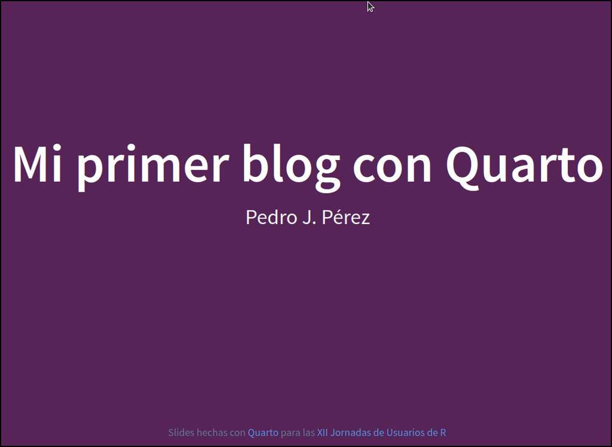

Gráfico 1: Una imagen que vamos a referenciar

Para referenciarla, para hacer referencia a esta imagen, en el texto de nuestro documento hemos de usar unas marcas: `@fig-001`. Por ejemplo si en nuestro documento fuente (.qmd) tenemos un párrafo como este:

```markdown
Como puede verse en @fig-001 nos hacemos a la idea de que .... Pedro no sabe buscar imÁgenes nuevas
```

Y veremos algo como esto:

Como puede verse en Figura 1 nos hacemos a la idea de que …. Pedro no sabe buscar imágenes nuevas

### Ahora referenciamos una tabla

Acuérdate que para referenciarla necesitaremos un label y una caption. Más abajo tienes la sintaxis para ello. Es un poco diferente a la de las tablas; ahora es: `: Mys notas {#tbl-001-notas}`

```markdown
+-------------------------------------+-----------------------------+
| Nombre                              | Nota                        |
+=====================================+=============================+
|     Pedro                           | 5                           |
+-------------------------------------+-----------------------------+
|     María                           | 11                          |
+-------------------------------------+-----------------------------+

: Mys notas {#tbl-001-notas}
```

Abajo puedes ver como quedaría la tabla:

Tabla 1: Mys notas

Nombre

Nota

```
Pedro
```

5

```
María
```

11

Para referenciarla, para hacer referencia a esta tabla, en el texto de nuestro documento hemos de usar unas marcas, en este caso `@tbl-001-notas`. Por ejemplo si en nuestro documento fuente (.qmd) tenemos un párrafo como este:

```markdown
Como puede verse en @@tbl-001-notas podemos ver las notas que han sacado Pedro y María ... Pedro no molt be!!
```

Podremos ver algo como lo siguiente:

Como puede verse en @Tabla 1 podemos ver las notas que han sacado Pedro y María … Pedro no molt be!!

## 4 Elementos referenciables

Como puedes ver en la [documentación oficial](https://quarto.org/docs/authoring/cross-references.html), también se pueden referenciar:

- las **imágenes creadas con código** (por ejemplo gráficos).
- las **tablas creadas con código**
- ecuaciones
- secciones de un documento
- chunks
- teoremas y pruebas
- capítulos

## 5 Más cosas

Hay muchos más detalles que nos permiten por ejemplo incluir un listado de figuras o de tablas; también podemos modificar las cross-references a nuestro gusto o al gusto de los editores, pero no los vamos a ver: os remito a la documentación oficial, [aquí](https://quarto.org/docs/authoring/cross-references.html) y [aquí](https://quarto.org/docs/books/book-crossrefs.html)

La documentación de las “text-references” y “cross-references” de Bookdown están [aquí](https://bookdown.org/yihui/rmarkdown/bookdown-markdown.html#text-references). No he probado si funcionan en Quarto.